# OkCupid Data Visualizations

Calais Michaelsson, Juliene Jones, Catherina Iltchev

2026-03-27

# 1 Setup

```r
library(tidyverse)
library(extrafont)
library(tidycensus)
library(dplyr)
library(stringr)
library(gtrendsR)
library(haven)
library(knitr)
library(kableExtra)
library(tibble)
library(ggplot2)
library(forcats)
library(scales)
```

```r
library(here)

df <- read.csv("/Users/julienejones/ECON216-GroupProject/okcupid_profiles.csv")
```

# 2 Essay Questions Data Cleaning:

### 2.0.1 Higher Education Keywords:

```r
high_education_keywords <- c(
  # Direct credentials
  "phd", "ph.d", "doctorate", "doctoral", "dissertation",
  "thesis", "postdoc", "post-doc", "grad school",
  "graduate school", "masters degree", "master's degree",
  "bachelor's degree", "bachelors degree",

  # Academic roles
  "professor", "faculty", "lecturer", "teaching assistant",
  "research assistant", "postdoctoral", "tenure",
  "tenured", "academic", "academia",

  # Research and publication
  "published", "publication", "peer reviewed", "peer-reviewed",
  "journal article", "research paper", "lab", "laboratory",
  "field work", "fieldwork", "grant", "fellowship",

  # Specific degree programs
  "law degree", "jd", "j.d", "md", "m\\.d", "mba", "m.b.a",
  "master of", "bachelor of", "doctor of",
  "phd candidate", "phd student", "doctoral candidate",
  "medical degree", "law degree",

  # Named institutions
  "harvard", "yale", "stanford", "mit", "princeton",
  "columbia", "cornell", "dartmouth", "brown", "upenn",
  "uchicago", "duke", "vanderbilt", "georgetown", "nyu",
  "ucla", "berkeley", "caltech",

  # Professional licensure tied to advanced degrees
  "bar exam", "passed the bar", "board certified",
  "licensed physician", "licensed attorney",
  "residency", "fellowship program", "medical residency"
)

high_edu_pattern <- paste(high_education_keywords, collapse = "|")

# ── Add flag to dataframe ──────────────────

df <- df %>%
  mutate(
    high_edu_signal = if_any(starts_with("essay"),
                             ~str_detect(., regex(high_edu_pattern,
                                                  ignore_case = TRUE)))
  )

# ── Keyword frequency table ────────────────

all_essays <- apply(dplyr::select(df, starts_with("essay")),
                    1, paste, collapse = " ")

map_dfr(high_education_keywords, function(kw) {
  tibble(
    keyword = kw,
    count   = sum(str_detect(all_essays,
                             regex(kw, ignore_case = TRUE)),
                  na.rm = TRUE),
    pct     = round(count / nrow(df) * 100, 2)
  )
}) %>%
  arrange(desc(count)) %>%
  filter(count > 0) %>%
  knitr::kable(col.names = c("Keyword", "Count", "% of Profiles"),
               caption = "High Education Credential Keyword Frequency")
```

High Education Credential Keyword Frequency

| Keyword | Count | % of Profiles |
| --- | --- | --- |
| mit | 12229 | 20.40 |
| lab | 5554 | 9.27 |
| j.d | 4893 | 8.16 |
| mba | 3453 | 5.76 |
| brown | 2596 | 4.33 |
| berkeley | 2503 | 4.18 |
| grad school | 1773 | 2.96 |
| grant | 981 | 1.64 |
| phd | 833 | 1.39 |
| md | 763 | 1.27 |
| m.b.a | 731 | 1.22 |
| academic | 643 | 1.07 |
| stanford | 592 | 0.99 |
| graduate school | 587 | 0.98 |
| professor | 455 | 0.76 |
| thesis | 381 | 0.64 |
| jd | 378 | 0.63 |
| published | 373 | 0.62 |
| yale | 363 | 0.61 |
| ph.d | 330 | 0.55 |
| master of | 278 | 0.46 |
| masters degree | 248 | 0.41 |
| duke | 235 | 0.39 |
| master’s degree | 227 | 0.38 |
| academia | 172 | 0.29 |
| residency | 144 | 0.24 |
| ucla | 141 | 0.24 |
| doctorate | 140 | 0.23 |
| publication | 136 | 0.23 |
| fellowship | 129 | 0.22 |
| dissertation | 123 | 0.21 |
| bachelor’s degree | 103 | 0.17 |
| columbia | 103 | 0.17 |
| harvard | 85 | 0.14 |
| cornell | 84 | 0.14 |
| nyu | 83 | 0.14 |
| bachelors degree | 82 | 0.14 |
| phd student | 74 | 0.12 |
| laboratory | 69 | 0.12 |
| m.d | 63 | 0.11 |
| doctoral | 57 | 0.10 |
| postdoc | 48 | 0.08 |
| bar exam | 46 | 0.08 |
| faculty | 37 | 0.06 |
| research assistant | 33 | 0.06 |
| bachelor of | 30 | 0.05 |
| journal article | 28 | 0.05 |
| law degree | 27 | 0.05 |
| law degree | 27 | 0.05 |
| post-doc | 26 | 0.04 |
| research paper | 26 | 0.04 |
| lecturer | 25 | 0.04 |
| tenure | 25 | 0.04 |
| princeton | 22 | 0.04 |
| teaching assistant | 14 | 0.02 |
| field work | 14 | 0.02 |
| georgetown | 14 | 0.02 |
| caltech | 14 | 0.02 |
| passed the bar | 13 | 0.02 |
| fieldwork | 11 | 0.02 |
| doctor of | 11 | 0.02 |
| phd candidate | 11 | 0.02 |
| vanderbilt | 9 | 0.02 |
| upenn | 8 | 0.01 |
| medical degree | 7 | 0.01 |
| postdoctoral | 6 | 0.01 |
| tenured | 6 | 0.01 |
| peer-reviewed | 5 | 0.01 |
| dartmouth | 5 | 0.01 |
| uchicago | 5 | 0.01 |
| medical residency | 5 | 0.01 |
| board certified | 3 | 0.01 |
| peer reviewed | 2 | 0.00 |
| licensed attorney | 1 | 0.00 |
| fellowship program | 1 | 0.00 |

```r
# ─────────────────────────────────────────
# Search a specific keyword and view
# 50 essay responses containing it
# ─────────────────────────────────────────

search_word <- "m.d"

# ─────────────────────────────────────────

# Define exact essay columns to avoid picking up flag columns
essay_cols <- paste0("essay", 0:9)

df %>%
  mutate(all_essays = apply(dplyr::select(., all_of(essay_cols)),
                            1, paste, collapse = " ")) %>%
  filter(str_detect(all_essays,
                    regex(search_word, ignore_case = TRUE))) %>%
  slice_sample(n = 50) %>%
  pivot_longer(cols = all_of(essay_cols),
               names_to = "essay_prompt",
               values_to = "response") %>%
  filter(str_detect(response,
                    regex(search_word, ignore_case = TRUE)),
         !is.na(response)) %>%
  mutate(
    essay_prompt = recode(essay_prompt,
      "essay0" = "Self Summary",
      "essay1" = "What I'm Doing With My Life",
      "essay2" = "I'm Really Good At",
      "essay3" = "First Thing People Notice",
      "essay4" = "Favorite Books/Movies/Music",
      "essay5" = "Six Things I Can't Live Without",
      "essay6" = "I Spend Thinking About",
      "essay7" = "Typical Friday Night",
      "essay8" = "Most Private Thing",
      "essay9" = "You Should Message Me If"
    ),
    response = str_remove_all(response, "<[^>]+>"),
    response = str_remove_all(response, "&[a-z]+;"),
    context  = str_extract(response,
                           paste0(".{0,80}",
                                  search_word,
                                  ".{0,80}"))
  ) %>%
  dplyr::select(age, sex, ethnicity, education,
                essay_prompt, context) %>%
  knitr::kable(
    col.names = c("Age", "Sex", "Ethnicity",
                  "Education", "Essay Prompt",
                  "Context (80 chars around match)"),
    caption = paste0("50 sample responses containing: '",
                     search_word, "'")
  )
```

| Age | Sex | Ethnicity | Education | Essay Prompt | Context (80 chars around match) |
| --- | --- | --- | --- | --- | --- |
| 39 | f | white | graduated from masters program | Self Summary | a little midwestern, a little city and a little homegrown! i’m a pretty straightforward, pla |
| 56 | f | white | graduated from college/university | I Spend Thinking About | paper, plastic or the bag made out of recycled materials that i left in the trunk! |
| 25 | f | other | graduated from masters program | I’m Really Good At | being a nomad. i move constantly and can’t stay still… life is too short to stay in one pla |
| 38 | f | hispanic / latin | dropped out of masters program | Self Summary | a foolish consistency. i am a perpetual middle child; autonomous, deliberate, gradual, humble, pensive, altruistic and at t |
| 38 | f | hispanic / latin | dropped out of masters program | What I’m Doing With My Life | sive politics, community organizing, and civic engagement. other things that i’m doing with my life: -championing the underdog -making and creating -aching for th |
| 38 | f | hispanic / latin | dropped out of masters program | Favorite Books/Movies/Music | daily show, jaime oliver’s food revolution, anthony bourdain: no reservations, modern family, friday night lights, 30 rock, frontline, sunday morning, alfred hitc |
| 38 | f | hispanic / latin | dropped out of masters program | You Should Message Me If | me and indulge me when i get all wonky over things like the brick rings in the middle of intersections, streets named for san francisco authors, and old architect |
| 25 | m | hispanic / latin, white, other | graduated from two-year college | Favorite Books/Movies/Music | els, comics… movies: tons shows: firefly, dollhouse, how i met your mother, modern family, chuck, shark week, buffy the vampire slayer, cash cab, the office, t |
| 30 | f | asian | graduated from masters program | Self Summary | want to go? what else.. grew up going to church, still pretty active.. i’m the middle child of three girls, and have a big extended family love to travel.. this |
| 30 | f | asian | graduated from masters program | Favorite Books/Movies/Music | sure there’s almost something every night of the week.. himym, glee, new girl, modern family, top chef, bones.. music - found this radio station in hawaii.. 93.9 |
| 25 | m | white | working on masters program | Most Private Thing | i am genetically deformed and cannot wake up after 9am. |
| 29 | m | other |  | What I’m Doing With My Life | it was pretty recent it seems dishonest not to mention it here. but now that i’m done with that, i am, lets see how do i put this, moving forward. |
| 29 | m | other |  | I’m Really Good At | having more clothes would solve the problem, so i bought a bunch, but this has made things worse. i’m also bad at not cuddling, caring about rainbows, and i hate |
| 29 | m | other |  | I Spend Thinking About | politics, how to improve my running, and what i’m doing with my life. |
| 33 | f |  | graduated from masters program | Self Summary | hy, physics, cars, and language. i have yet to be interested in how linoleum is made but maybe there is a good story in it somewhere. to conclude this summary, i w |
| 33 | f |  | graduated from masters program | I’m Really Good At | hat i’m not good at. i’m terrible at tennis. not a great speller. not good at immediately responding to emails and texts (but almost always eventually do). not goo |
| 30 | m | white | graduated from college/university | Self Summary | eso.” sometimes i get possessed by the spirit of the 1920’s, particularly if i’m drinking bourbon… desired obituary: “wealthy gadabout, mischievous rapscallion |
| 30 | m | white | graduated from college/university | Favorite Books/Movies/Music | a great appreciation for and interest in mississippi delta blues artists, like muddy waters, robert johnson, etc. food- japanese and thai are two of my favorite, |
| 30 | m | white | graduated from college/university | Six Things I Can’t Live Without | in time: –“he was born with a gift of laughter and a sense that the world was mad.” -scaramouche -random observation: people who go out all the time are very lo |
| 30 | m | white | graduated from college/university | You Should Message Me If | take a while getting back to you. okcupid says i am perpetually online, but i am definitely not.* |
| 38 | m | white | working on ph.d program | Self Summary | ly type and disappointing us both; if i wanted that, i would have stayed in the midwest! i’ve checked “casual sex” as i’m guessing that the person i’m looking for |
| 38 | m | white | working on ph.d program | Favorite Books/Movies/Music | dark comedies, documentaries, well-written dramatic series. sci-fi, fantasy, any media ex |
| 24 | m | white | graduated from college/university | Favorite Books/Movies/Music | ts, and city of god. outside of those i usually go for thrillers, dramas, or comedies. i’ll watch horror but i’m not a fan. if i know a film is a remake of a for |
| 24 | m | white | graduated from college/university | Most Private Thing | one of my goals in life is to someday grow a fu man chu mustache and then try to stare down random people on the st |
| 35 | m | black, white | graduated from college/university | Six Things I Can’t Live Without | skey neat breakfast conversationalists the serendipity of shuffle toro a well timed lebowski or pulp fiction quote green vibrance podcasts mind blowing books, albu |
| 30 | m |  | working on college/university | I’m Really Good At | making it look like i know what i’m doing (all guys do this, it’s a secret). being care-free and modest. for some rea |
| 39 | m | black | graduated from college/university | Self Summary | ) if you are somewhat athletic*(hiking, cycling, surfing, inline skating, yoga, modeling or snowboarding) this is a definite plus. can you help prune the vines in |
| 39 | m | black | graduated from college/university | You Should Message Me If | ) if you are somewhat athletic*(hiking, cycling, surfing, inline skating, yoga, modeling or snowboarding) this is a definite plus. can you help prune the vines in |
| 25 | m | white | graduated from college/university | Self Summary | or at home watching a movie. seeing a theatre performance, live music, improv, midnight showings of the rocky horror picture show are also lots of fun! |
| 25 | m | white | graduated from college/university | Favorite Books/Movies/Music | re dexter, the wire, freaks and geeks, it’s always sunny in philadelphia, rome, madmen, house, and game of thrones. music: i just saw my favorite band, muse, in c |

[output cut: 64 more lines]

### 2.0.3 Geographic breakdown:

```r
# ─────────────────────────────────────────
# Geographic Breakdown of OKCupid Dataset
# ─────────────────────────────────────────

# ── Step 1: Parse city and state ───────────

df <- df %>%
  mutate(
    city  = str_trim(str_extract(location, "^[^,]+")),
    state = str_trim(str_extract(location, "(?<=,\\s).*$"))
  )

# ── Step 2: City breakdown ─────────────────

df %>%
  count(city, sort = TRUE) %>%
  filter(!is.na(city)) %>%
  mutate(pct = round(n / nrow(df) * 100, 2)) %>%
  knitr::kable(
    col.names = c("City", "Count", "% of Profiles"),
    caption   = "Profile Count by City"
  )
```

Profile Count by City

| City | Count | % of Profiles |
| --- | --- | --- |
| san francisco | 31064 | 51.82 |
| oakland | 7214 | 12.03 |
| berkeley | 4212 | 7.03 |
| san mateo | 1331 | 2.22 |
| palo alto | 1064 | 1.77 |
| alameda | 910 | 1.52 |
| san rafael | 755 | 1.26 |
| hayward | 747 | 1.25 |
| emeryville | 738 | 1.23 |
| redwood city | 693 | 1.16 |
| daly city | 681 | 1.14 |
| san leandro | 651 | 1.09 |
| walnut creek | 644 | 1.07 |
| vallejo | 558 | 0.93 |
| menlo park | 479 | 0.80 |
| richmond | 424 | 0.71 |
| south san francisco | 416 | 0.69 |
| mountain view | 384 | 0.64 |
| novato | 369 | 0.62 |
| burlingame | 361 | 0.60 |
| pleasant hill | 347 | 0.58 |
| castro valley | 345 | 0.58 |
| stanford | 341 | 0.57 |
| el cerrito | 325 | 0.54 |
| pacifica | 323 | 0.54 |
| martinez | 316 | 0.53 |
| mill valley | 315 | 0.53 |
| san bruno | 290 | 0.48 |
| san pablo | 245 | 0.41 |
| belmont | 243 | 0.41 |

[output cut: 168 more lines]

```r
# ── Step 3: State breakdown ─────────────────

df %>%
  count(state, sort = TRUE) %>%
  filter(!is.na(state)) %>%
  mutate(pct = round(n / nrow(df) * 100, 2)) %>%
  knitr::kable(
    col.names = c("State", "Count", "% of Profiles"),
    caption   = "Profile Count by State"
  )
```

Profile Count by State

| State | Count | % of Profiles |
| --- | --- | --- |
| california | 59855 | 99.85 |
| new york | 17 | 0.03 |
| illinois | 8 | 0.01 |
| massachusetts | 5 | 0.01 |
| michigan | 4 | 0.01 |
| oregon | 4 | 0.01 |
| texas | 4 | 0.01 |
| arizona | 3 | 0.01 |
| florida | 3 | 0.01 |
| colorado | 2 | 0.00 |
| district of columbia | 2 | 0.00 |
| georgia | 2 | 0.00 |
| hawaii | 2 | 0.00 |
| minnesota | 2 | 0.00 |
| ohio | 2 | 0.00 |
| spain | 2 | 0.00 |
| united kingdom | 2 | 0.00 |
| utah | 2 | 0.00 |
| virginia | 2 | 0.00 |
| washington | 2 | 0.00 |
| british columbia, canada | 1 | 0.00 |
| connecticut | 1 | 0.00 |
| germany | 1 | 0.00 |
| idaho | 1 | 0.00 |
| ireland | 1 | 0.00 |
| louisiana | 1 | 0.00 |
| mexico | 1 | 0.00 |
| mississippi | 1 | 0.00 |
| missouri | 1 | 0.00 |
| montana | 1 | 0.00 |
| netherlands | 1 | 0.00 |
| nevada | 1 | 0.00 |
| new jersey | 1 | 0.00 |
| north carolina | 1 | 0.00 |
| pennsylvania | 1 | 0.00 |
| rhode island | 1 | 0.00 |
| switzerland | 1 | 0.00 |
| tennessee | 1 | 0.00 |
| vietnam | 1 | 0.00 |
| west virginia | 1 | 0.00 |
| wisconsin | 1 | 0.00 |

### 2.0.4 Response Counts:

```r
# ─────────────────────────────────────────
# Response count for each essay prompt
# ─────────────────────────────────────────

essay_cols <- paste0("essay", 0:9)

essay_labels <- c(
  "essay0" = "Self Summary",
  "essay1" = "What I'm Doing With My Life",
  "essay2" = "I'm Really Good At",
  "essay3" = "First Thing People Notice",
  "essay4" = "Favorite Books/Movies/Music",
  "essay5" = "Six Things I Can't Live Without",
  "essay6" = "I Spend Thinking About",
  "essay7" = "Typical Friday Night",
  "essay8" = "Most Private Thing",
  "essay9" = "You Should Message Me If"
)

map_dfr(essay_cols, function(e) {
  tibble(
    essay         = essay_labels[e],
    total         = nrow(df),
    responded     = sum(!is.na(df[[e]]) &
                        str_trim(df[[e]]) != "",
                        na.rm = TRUE),
    no_response   = total - responded,
    pct_responded = round(responded / total * 100, 1)
  )
}) %>%
  arrange(desc(responded)) %>%
  knitr::kable(
    col.names = c("Essay Prompt", "Total Profiles",
                  "Responded", "No Response",
                  "% Responded"),
    caption = "Response Rate by Essay Prompt"
  )
```

Response Rate by Essay Prompt

| Essay Prompt | Total Profiles | Responded | No Response | % Responded |
| --- | --- | --- | --- | --- |
| Self Summary | 59946 | 54457 | 5489 | 90.8 |
| What I’m Doing With My Life | 59946 | 52374 | 7572 | 87.4 |
| I’m Really Good At | 59946 | 50308 | 9638 | 83.9 |
| Favorite Books/Movies/Music | 59946 | 49409 | 10537 | 82.4 |
| Six Things I Can’t Live Without | 59946 | 49096 | 10850 | 81.9 |
| First Thing People Notice | 59946 | 48470 | 11476 | 80.9 |
| Typical Friday Night | 59946 | 47495 | 12451 | 79.2 |
| You Should Message Me If | 59946 | 47343 | 12603 | 79.0 |
| I Spend Thinking About | 59946 | 46175 | 13771 | 77.0 |
| Most Private Thing | 59946 | 40721 | 19225 | 67.9 |

# 3 Variable Visualizations

## 3.1 Univariate Variable Visualizations

#### 3.1.0.1 age status sex orientation body_type diet drinks

#### 3.1.0.2 Drug usage:

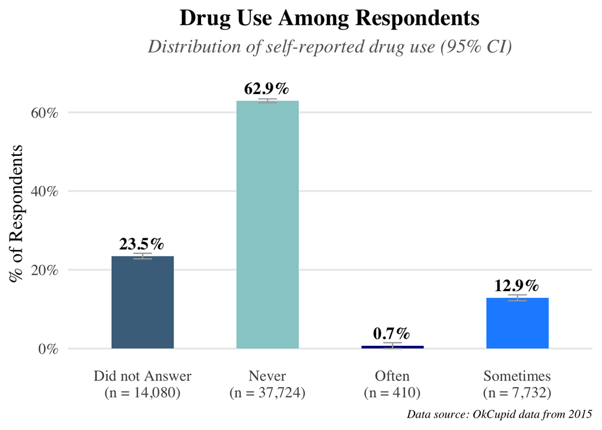

```r
univariate_drugs <- df %>%
  mutate(
    drugs = fct_explicit_na(
      factor(drugs, levels = c("never", "sometimes", "often")),
      na_level = "Did not answer"
    )
  ) %>%
  count(drugs) %>%
  mutate(
    total = sum(n),
    pct = n / total,
    se = sqrt(pct * (1 - pct) / n),
    ci_low = pmax(0, pct - 1.96 * se),
    ci_high = pmin(1, pct + 1.96 * se),
    drugs_label = paste0(
      tools::toTitleCase(as.character(drugs)),
      "\n(n = ", comma(n), ")"
    )
  )

ggplot(univariate_drugs, aes(x = drugs_label, y = pct, fill = drugs)) +
  geom_col(width = 0.5, show.legend = FALSE) +

  geom_errorbar(
    aes(ymin = ci_low, ymax = ci_high),
    width = 0.15,
    size = 0.8,
    linewidth = 0.5,
    color = "darkgrey"
  ) +

  geom_text(
    aes(label = percent(pct, accuracy = 0.1)),
    vjust = -0.6,
    fontface = "bold",
    size = 5,
    family = "serif"
  ) +

  scale_y_continuous(
    labels = percent_format(accuracy = 1),
    limits = c(0, max(univariate_drugs$ci_high) + 0.05)
  ) +

  scale_fill_manual(
    values = c(
      "never" = "#96CDCD",
      "sometimes" = "#1E90FF",
      "often" = "#00008B",
      "Did not answer" = "#4A708B"
    )
  ) +

  labs(
    title = "Drug Use Among Respondents",
    subtitle = "Distribution of self-reported drug use (95% CI)",
    x = NULL,
    y = "% of Respondents",
        caption = "Data source: OkCupid data from 2015"

  ) +

  theme_minimal(base_size = 16) +
  theme(
    plot.title = element_text(face = "bold", hjust = 0.5, family = "serif"),
    plot.subtitle = element_text(hjust = 0.5, face = "italic", color = "gray40", family = "serif"),
    axis.title.y = element_text(family = "serif"),
    axis.text.x = element_text(family = "serif"),
    axis.text.y = element_text(family = "serif"),
    panel.grid.minor = element_blank(),
    panel.grid.major.x = element_blank(),
    plot.caption = element_text(face = "italic", color = "black", family = "serif", size = 10)

  )
```

```r
ggsave(
  filename = "Univariate_drug_use.png",
  bg = "white"
)
```

#### 3.1.0.4 Ethnicity:

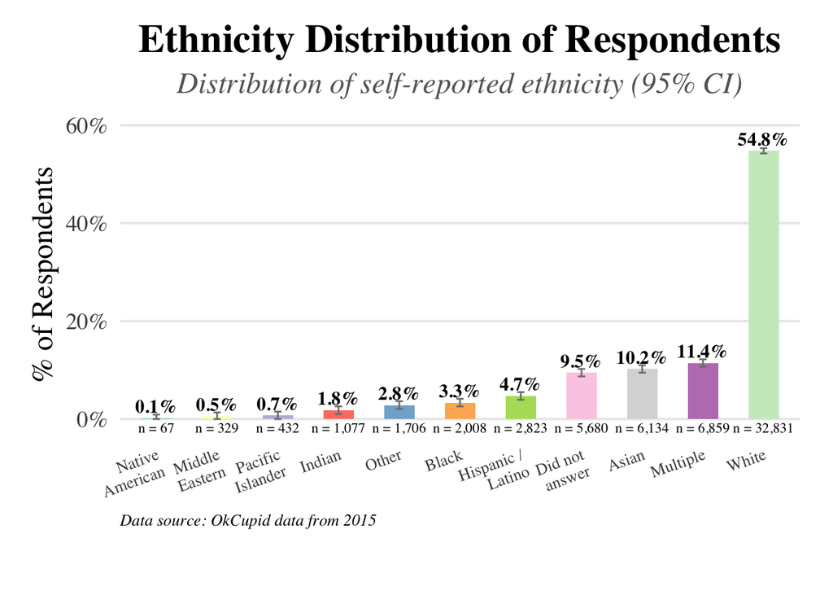

```r
univariate_ethnicity <- df %>%
  mutate(
    ethnicity = case_when(
      is.na(ethnicity) | ethnicity == "" ~ "Did not answer",
      str_detect(ethnicity, ",") ~ "multiple",
      TRUE ~ ethnicity
    ),
    ethnicity = as.factor(ethnicity)
  ) %>%
  count(ethnicity) %>%
  mutate(
    total = sum(n),
    pct = n / total,
    se = sqrt(pct * (1 - pct) / n),
    ci_low = pmax(0, pct - 1.96 * se),
    ci_high = pmin(1, pct + 1.96 * se),
    ethnicity_clean = case_when(
      ethnicity == "asian" ~ "Asian",
      ethnicity == "black" ~ "Black",
      ethnicity == "hispanic / latin" ~ "Hispanic /\nLatino",
      ethnicity == "indian" ~ "Indian",
      ethnicity == "middle eastern" ~ "Middle\nEastern",
      ethnicity == "native american" ~ "Native\nAmerican",
      ethnicity == "other" ~ "Other",
      ethnicity == "pacific islander" ~ "Pacific\nIslander",
      ethnicity == "multiple" ~ "Multiple",
      ethnicity == "white" ~ "White",
      ethnicity == "Did not answer" ~ "Did not\nanswer",
      TRUE ~ tools::toTitleCase(as.character(ethnicity))
    ),
    n_label = paste0("n = ", comma(n), "")
  ) %>%
  mutate(
    ethnicity_clean = factor(
      ethnicity_clean,
      levels = ethnicity_clean[order(pct)]
    )
  )

ggplot(univariate_ethnicity, aes(x = ethnicity_clean, y = pct, fill = ethnicity_clean)) +
  geom_col(width = 0.5, show.legend = FALSE) +
  geom_errorbar(
    aes(ymin = ci_low, ymax = ci_high),
    width = 0.12,
    linewidth = 0.5,
    color = "gray50"
  ) +
  geom_text(
    aes(label = percent(pct, accuracy = 0.1)),
    vjust = -0.45,
    fontface = "bold",
    size = 4,
    family = "serif"
  ) +
  geom_text(
    aes(y = -0.018, label = n_label),
    size = 3,
    family = "serif",
    color = "black"
  ) +
  scale_y_continuous(
    labels = percent_format(accuracy = 1),
    limits = c(-0.035, max(univariate_ethnicity$ci_high) + 0.06),
    expand = expansion(mult = c(0, 0.02))
  ) +
  scale_fill_brewer(palette = "Set3") +
  coord_cartesian(clip = "off") +
  labs(
    title = "Ethnicity Distribution of Respondents",
    subtitle = "Distribution of self-reported ethnicity (95% CI)",
    x = NULL,
    y = "% of Respondents",
    caption = "Data source: OkCupid data from 2015"
  ) +
  theme_minimal(base_size = 16) +
  theme(
    plot.title = element_text(face = "bold", hjust = 0.5, family = "serif", size = 24),
    plot.subtitle = element_text(hjust = 0.5, face = "italic", color = "gray40", family = "serif", size = 18),
    axis.title.y = element_text(family = "serif", size = 18),
    axis.text.x = element_text(
      family = "serif",
      size = 10,
      angle = 20,
      hjust = 1,
      lineheight = 0.9,
      margin = margin(t = 10)
    ),
    axis.text.y = element_text(family = "serif", size = 14),
    panel.grid.minor = element_blank(),
    panel.grid.major.x = element_blank(),
    plot.margin = margin(15, 20, 40, 20),
    plot.caption = element_text(
      face = "italic",
      color = "black",
      family = "serif",
      size = 10,
      hjust = 0
    )
  )
```

```r
ggsave(
  filename = "Univariate_ethnicity.png",
  bg = "white"
)
```

#### 3.1.0.9 location offspring pets religion sign smokes speaks

## 3.2 Bivariate Visualizations

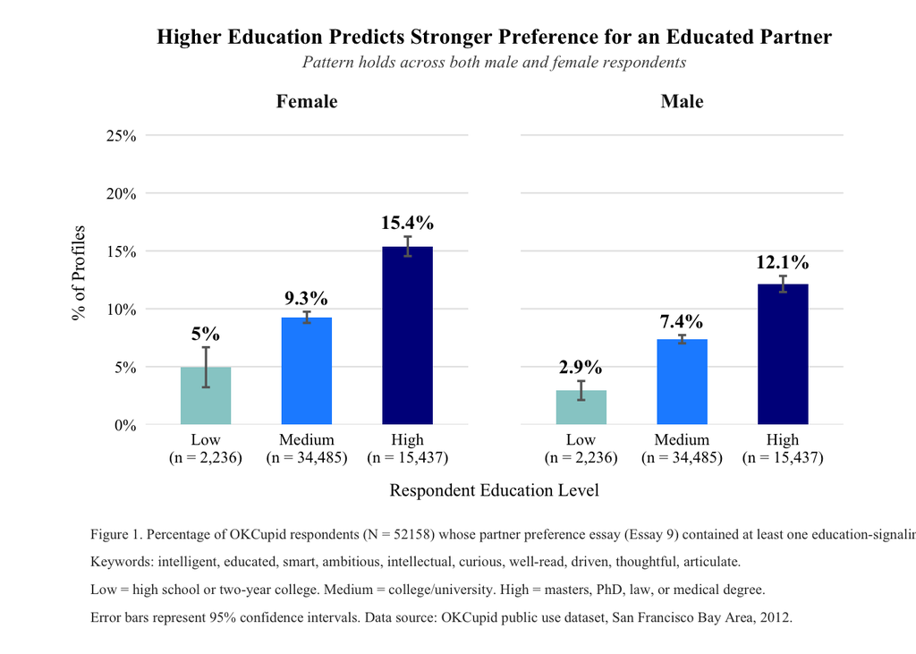

```r
library(extrafont)
loadfonts(quiet = TRUE)

df <- df %>%
  mutate(
    # Clean essay9 first
    essay9_clean = str_remove_all(essay9, "<[^>]+>"),
    essay9_clean = str_remove_all(essay9_clean, "&[a-z]+;"),

    # Educated partner signal
    signals_educated_partner = str_detect(
      essay9_clean,
      regex("intelligent|educated|smart|ambitious|intellectual|curious|well-read|driven|thoughtful|articulate",
            ignore_case = TRUE)
    ),

    # Education tier
    edu_tier = case_when(
      str_detect(education, regex("ph\\.?d|master|law school|med school|doctoral", ignore_case = TRUE)) ~ "High",
      str_detect(education, regex("college|university|bachelor", ignore_case = TRUE)) ~ "Medium",
      str_detect(education, regex("high school|two-year|dropped out", ignore_case = TRUE)) ~ "Low",
      TRUE ~ NA_character_
    ),
    edu_tier = factor(edu_tier, levels = c("Low", "Medium", "High"))
  )

# ── Prep data with sample sizes and CIs ────

plot_data <- df %>%
  filter(!is.na(edu_tier), !is.na(signals_educated_partner),
         !is.na(sex)) %>%
  mutate(sex = recode(sex, "m" = "Male", "f" = "Female")) %>%
  group_by(edu_tier, sex) %>%
  summarise(
    n        = n(),
    mentions = sum(signals_educated_partner, na.rm = TRUE),
    pct      = mentions / n * 100,
    se       = sqrt((pct/100 * (1 - pct/100)) / n) * 100,
    ci_lower = pct - 1.96 * se,
    ci_upper = pct + 1.96 * se,
    .groups  = "drop"
  )

# ── Sample size labels for x-axis ──────────

edu_labels <- plot_data %>%
  group_by(edu_tier) %>%
  summarise(n_total = sum(n)) %>%
  mutate(label = paste0(edu_tier, "\n(n = ",
                        scales::comma(n_total), ")")) %>%
  dplyr::select(edu_tier, label) %>%
  deframe()

# ── Plot ────────────────────────────────────

plot_data %>%
  ggplot(aes(x = edu_tier, y = pct, fill = edu_tier)) +
  geom_col(width = 0.5) +
  geom_errorbar(aes(ymin = ci_lower, ymax = ci_upper),
                width = 0.08, color = "grey40",
                linewidth = 0.6) +
geom_text(aes(label = paste0(round(pct, 1), "%"),
              y = ci_upper),
          vjust = -0.6, size = 3.8,
          family = "Times New Roman",
          fontface = "bold") +
  facet_wrap(~sex) +
  scale_fill_manual(values = c(
    "Low"    = "#96CDCD",
    "Medium" = "#1E90FF",
    "High"   = "#00008B"
  )) +
  scale_x_discrete(labels = edu_labels) +
  scale_y_continuous(
    limits = c(0, 25),
    breaks = seq(0, 25, by = 5),
    labels = paste0(seq(0, 25, by = 5), "%"),
    expand = expansion(mult = c(0, 0.05))
  ) +
  labs(
    title    = "Higher Education Predicts Stronger Preference for an Educated Partner",
    subtitle = "Pattern holds across both male and female respondents",
    x        = "Respondent Education Level",
    y        = "% of Profiles",
caption  = paste0(
  "Figure 1. Percentage of OKCupid respondents (N = ",
  nrow(df %>% filter(!is.na(edu_tier), !is.na(sex))),
  ") whose partner preference essay (Essay 9) contained at least one education-signaling keyword.\n",
  "Keywords: intelligent, educated, smart, ambitious, intellectual, curious, well-read, driven, thoughtful, articulate.\n",
  "Low = high school or two-year college. Medium = college/university. High = masters, PhD, law, or medical degree.\n",
  "Error bars represent 95% confidence intervals. Data source: OKCupid public use dataset, San Francisco Bay Area, 2012."
)
  ) +
  theme_minimal(base_family = "Times New Roman") +
  theme(
    plot.title            = element_text(face = "bold", size = 12,
                                         hjust = 0.5,
                                         margin = margin(b = 4)),
    plot.subtitle         = element_text(size = 9.5, hjust = 0.5,
                                         color = "grey30",
                                         lineheight = 1.4,
                                         face = "italic",
                                         margin = margin(b = 12)),
    strip.text            = element_text(face = "bold", size = 11,
                                         family = "Times New Roman",
                                         margin = margin(b = 6)),
    axis.title.x          = element_text(size = 10,
                                         margin = margin(t = 10)),
    axis.title.y          = element_text(size = 10,
                                         margin = margin(r = 10)),
    axis.text             = element_text(size = 9, color = "black"),
    panel.grid.major.x    = element_blank(),
    panel.grid.minor      = element_blank(),
    panel.grid.major.y    = element_line(color = "grey90",
                                         linewidth = 0.4),
    panel.spacing         = unit(2, "lines"),
    plot.caption          = element_text(size = 8, hjust = 0,
                                         color = "grey20",
                                         lineheight = 1.6,
                                         face = "plain",
                                         margin = margin(t = 16, l = 10)),
    plot.caption.position = "plot",
    plot.margin           = margin(t = 16, r = 40, b = 16, l = 40),
    legend.position       = "none"
  )
```

```r
ggsave(
  filename = "EducationAssortativeMating_ByGender.png",
  plot     = last_plot(),
  width    = 12,
  height   = 7,
  dpi      = 300,
  bg       = "white"
)
```

This figure shows the percentage of OKCupid respondents whose partner preference essay contained at least one education-signaling keyword, broken down by respondent education level and gender. Higher education is associated with stronger preference signaling for an educated partner across both sexes, with highly educated female respondents signaling at the highest rate (15.4%) and the gradient being steeper among women than men. This raises the question of whether the gender asymmetry reflects differential returns to education in the marriage market, or whether highly educated women face a smaller pool of equally educated partners and thus signal more explicitly to filter candidates.

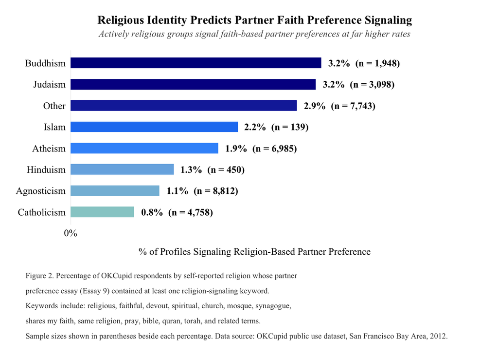

```r
# ─────────────────────────────────────────
# Religion signaling keywords in Essay 9
# by self-reported religion
# ─────────────────────────────────────────

# ── Step 1: Religion signal keywords ───────

religion_signal_keywords <- c(
  # Explicit preference language
  "religious", "faith", "faithful", "devout", "practicing",
  "spiritual", "god-fearing", "god fearing", "church",
  "mosque", "synagogue", "temple", "worship",

  # Partner faith preference
  "shares my faith", "share my faith", "same religion",
  "same faith", "similar beliefs", "similar values",
  "believes in god", "belief in god", "christian",
  "muslim", "jewish", "catholic", "buddhist", "hindu",
  "agnostic", "atheist",

  # Practice signals
  "pray", "prayer", "bible", "quran", "torah",
  "sabbath", "mass", "halal", "kosher", "meditate",
  "meditation", "spirituality"
)

religion_signal_pattern <- paste(religion_signal_keywords,
                                  collapse = "|")

# ── Step 2: Clean religion field and
#    add signal flag ──────────────────────

df <- df %>%
  mutate(
    essay9_clean = str_remove_all(essay9, "<[^>]+>"),
    essay9_clean = str_remove_all(essay9_clean, "&[a-z]+;"),
    religion_simple = str_extract(
      religion,
      regex("agnosticism|atheism|buddhism|catholicism|
             christianity|hinduism|islam|judaism|other",
            ignore_case = TRUE)
    ),
    religion_simple = str_to_title(religion_simple),
    signals_religion_partner = str_detect(
      essay9_clean,
      regex(religion_signal_pattern, ignore_case = TRUE)
    )
  )

# ── Step 3: Prep plot data ──────────────────

plot_data_rel <- df %>%
  filter(!is.na(religion_simple),
         !is.na(signals_religion_partner)) %>%
  group_by(religion_simple) %>%
  summarise(
    n        = n(),
    mentions = sum(signals_religion_partner, na.rm = TRUE),
    pct      = mentions / n * 100,
    .groups  = "drop"
  )

# ── Step 4: Plot ────────────────────────────

plot_data_rel %>%
  ggplot(aes(x = reorder(religion_simple, pct),
             y = pct,
             fill = pct)) +
  geom_col(width = 0.5) +
  geom_text(aes(label = paste0(round(pct, 1), "%  (n = ",
                               scales::comma(n), ")")),
            hjust = -0.1, size = 3.5,
            family = "Times New Roman",
            fontface = "bold") +
  coord_flip() +
  scale_fill_gradientn(
    colors = c("#96CDCD", "#1E90FF", "#00008B")
  ) +
  scale_y_continuous(
    limits = c(0, max(plot_data_rel$pct) * 1.4),
    breaks = seq(0,
                 ceiling(max(plot_data_rel$pct) * 1.4 / 5) * 5,
                 by = 5),
    labels = function(x) paste0(x, "%"),
    expand = expansion(mult = c(0, 0.05))
  ) +
  labs(
    title    = "Religious Identity Predicts Partner Faith Preference Signaling",
    subtitle = "Actively religious groups signal faith-based partner preferences at far higher rates",
    x        = NULL,
    y        = "% of Profiles Signaling Religion-Based Partner Preference",
    caption  = paste0(
      "Figure 2. Percentage of OKCupid respondents by self-reported religion whose partner\n",
      "preference essay (Essay 9) contained at least one religion-signaling keyword.\n",
      "Keywords include: religious, faithful, devout, spiritual, church, mosque, synagogue,\n",
      "shares my faith, same religion, pray, bible, quran, torah, and related terms.\n",
      "Sample sizes shown in parentheses beside each percentage. ",
      "Data source: OKCupid public use dataset, San Francisco Bay Area, 2012."
    )
  ) +
  theme_minimal(base_family = "Times New Roman") +
  theme(
    plot.title            = element_text(face = "bold", size = 12,
                                         hjust = 0.5,
                                         margin = margin(b = 4)),
    plot.subtitle         = element_text(size = 9.5, hjust = 0.5,
                                         color = "grey30",
                                         lineheight = 1.4,
                                         face = "italic",
                                         margin = margin(b = 12)),
    axis.title.x          = element_text(size = 10,
                                         margin = margin(t = 10)),
    axis.title.y          = element_text(size = 10,
                                         margin = margin(r = 10)),
    axis.text             = element_text(size = 10, color = "black"),
    panel.grid.major.y    = element_blank(),
    panel.grid.minor      = element_blank(),
    panel.grid.major.x    = element_line(color = "grey90",
                                         linewidth = 0.4),
    plot.caption          = element_text(size = 8, hjust = 0,
                                         color = "grey20",
                                         lineheight = 1.6,
                                         face = "plain",
                                         margin = margin(t = 16, l = 10)),
    plot.caption.position = "plot",
    plot.margin           = margin(t = 16, r = 60, b = 16, l = 16),
    legend.position       = "none"
  )
```

```r
ggsave(
  filename = "ReligionSignaling.png",
  plot     = last_plot(),
  width    = 10,
  height   = 6,
  dpi      = 300,
  bg       = "white"
)
```

This figure displays the rate at which respondents from each religious group explicitly signal a preference for a faith-matched partner in their Essay 9. Buddhist and Jewish respondents signal at the highest rates (both 3.2%), while agnostic and Catholic respondents signal at the lowest, suggesting that minority or more culturally cohesive religious identities predict stronger in-group partner preference. This leads to the question of whether high-signaling groups are driven by genuine theological requirements for endogamy or by social and community pressures that make out-group partnership more costly.

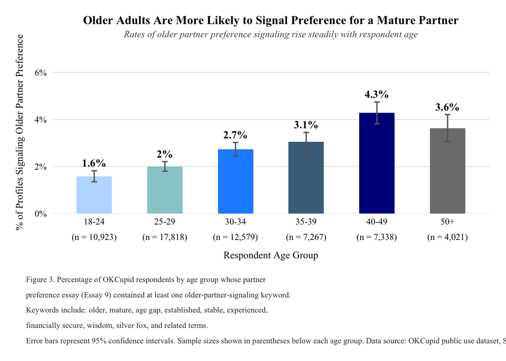

```r
# ─────────────────────────────────────────
# Older partner preference signaling
# by age group
# ─────────────────────────────────────────

# ── Step 1: Older partner signal keywords ──

older_partner_keywords <- c(
  # Direct age preference
  "older", "mature", "older man", "older woman",
  "older guy", "older girl", "age gap", "age difference",
  "younger than me", "older than me",

  # Maturity signals
  "mature man", "mature woman", "mature person",
  "established", "settled", "knows what he wants",
  "knows what she wants", "knows what they want",
  "has his life together", "has her life together",
  "financially stable", "financially secure",
  "stable", "grounded", "seasoned",

  # Experience signals
  "experienced", "worldly", "been around",
  "life experience", "wisdom", "wise",

  # Explicit age mentions
  "40s", "50s", "60s", "40's", "50's", "60's",
  "over 40", "over 50", "over 35", "older partner",
  "silver fox", "cougar", "cub"
)

older_partner_pattern <- paste(older_partner_keywords,
                                collapse = "|")

# ── Step 2: Add age group and signal flag ──

df <- df %>%
  mutate(
    essay9_clean = str_remove_all(essay9, "<[^>]+>"),
    essay9_clean = str_remove_all(essay9_clean, "&[a-z]+;"),
    age_group = case_when(
      age >= 18 & age <= 24 ~ "18-24",
      age >= 25 & age <= 29 ~ "25-29",
      age >= 30 & age <= 34 ~ "30-34",
      age >= 35 & age <= 39 ~ "35-39",
      age >= 40 & age <= 49 ~ "40-49",
      age >= 50             ~ "50+",
      TRUE                  ~ NA_character_
    ),
    age_group = factor(age_group, levels = c(
      "18-24", "25-29", "30-34",
      "35-39", "40-49", "50+"
    )),
    signals_older_partner = str_detect(
      essay9_clean,
      regex(older_partner_pattern, ignore_case = TRUE)
    )
  )

# ── Prep plot data with CIs ─────────────────

plot_data_age <- df %>%
  filter(!is.na(age_group),
         !is.na(signals_older_partner)) %>%
  group_by(age_group) %>%
  summarise(
    n        = n(),
    mentions = sum(signals_older_partner, na.rm = TRUE),
    pct      = mentions / n * 100,
    se       = sqrt((pct/100 * (1 - pct/100)) / n) * 100,
    ci_lower = pct - 1.96 * se,
    ci_upper = pct + 1.96 * se,
    .groups  = "drop"
  )

# ── Build x-axis labels with n= underneath ─

age_labels <- plot_data_age %>%
  mutate(label = paste0(age_group, "\n(n = ",
                        scales::comma(n), ")")) %>%
  dplyr::select(age_group, label) %>%
  deframe()

# ── Plot ────────────────────────────────────

plot_data_age %>%
  ggplot(aes(x = age_group, y = pct, fill = age_group)) +
  geom_col(width = 0.5) +
  geom_errorbar(aes(ymin = ci_lower, ymax = ci_upper),
                width = 0.08, color = "grey40",
                linewidth = 0.6) +
geom_text(aes(label = paste0(round(pct, 1), "%"),
              y = ci_upper),
          vjust = -0.6, size = 3.8,
          family = "Times New Roman",
          fontface = "bold") +
  scale_x_discrete(labels = age_labels) +
  scale_fill_manual(values = c(
    "18-24" = "#BBDDFF",
    "25-29" = "#96CDCD",
    "30-34" = "#1E90FF",
    "35-39" = "#4A708B",
    "40-49" = "#00008B",
    "50+"   = "#7D7D7D"
  )) +
  scale_y_continuous(
    limits = c(0, max(plot_data_age$ci_upper) * 1.35),
    breaks = seq(0,
                 ceiling(max(plot_data_age$ci_upper) * 1.35 / 2) * 2,
                 by = 2),
    labels = function(x) paste0(x, "%"),
    expand = expansion(mult = c(0, 0.08))
  ) +
  labs(
    title    = "Older Adults Are More Likely to Signal Preference for a Mature Partner",
    subtitle = "Rates of older partner preference signaling rise steadily with respondent age",
    x        = "Respondent Age Group",
    y        = "% of Profiles Signaling Older Partner Preference",
    caption  = paste0(
      "Figure 3. Percentage of OKCupid respondents by age group whose partner\n",
      "preference essay (Essay 9) contained at least one older-partner-signaling keyword.\n",
      "Keywords include: older, mature, age gap, established, stable, experienced,\n",
      "financially secure, wisdom, silver fox, and related terms.\n",
      "Error bars represent 95% confidence intervals. ",
      "Sample sizes shown in parentheses below each age group. ",
      "Data source: OKCupid public use dataset, San Francisco Bay Area, 2012."
    )
  ) +
  theme_minimal(base_family = "Times New Roman") +
  theme(
    plot.title            = element_text(face = "bold", size = 12,
                                         hjust = 0.5,
                                         margin = margin(b = 4)),
    plot.subtitle         = element_text(size = 9.5, hjust = 0.5,
                                         color = "grey30",
                                         lineheight = 1.4,
                                         face = "italic",
                                         margin = margin(b = 12)),
    axis.title.x          = element_text(size = 10,
                                         margin = margin(t = 10)),
    axis.title.y          = element_text(size = 10,
                                         margin = margin(r = 10)),
    axis.text.x           = element_text(size = 9, color = "black",
                                         lineheight = 1.4),
    axis.text.y           = element_text(size = 9, color = "black"),
    panel.grid.major.x    = element_blank(),
    panel.grid.minor      = element_blank(),
    panel.grid.major.y    = element_line(color = "grey90",
                                         linewidth = 0.4),
    plot.caption          = element_text(size = 8, hjust = 0,
                                         color = "grey20",
                                         lineheight = 1.6,
                                         face = "plain",
                                         margin = margin(t = 16, l = 10)),
    plot.caption.position = "plot",
    plot.margin           = margin(t = 16, r = 16, b = 16, l = 16),
    legend.position       = "none"
  )
```

```r
ggsave(
  filename = "OlderPartnerSignaling.png",
  plot     = last_plot(),
  width    = 10,
  height   = 6,
  dpi      = 300,
  bg       = "white"
)
```

This figure plots the share of respondents in each age group who signal a preference for a mature or older partner in their essay, revealing a near-monotonic increase from 1.6% among 18-24 year olds to 4.3% among 40-49 year olds. The pattern is consistent with life-stage explanations: older users may increasingly value markers of stability, financial security, and emotional maturity over youth-associated traits. This invites a follow-up question about whether the slight dip at 50+ reflects a ceiling effect, a shift toward same-age rather than older preferences, or simply smaller sample noise.

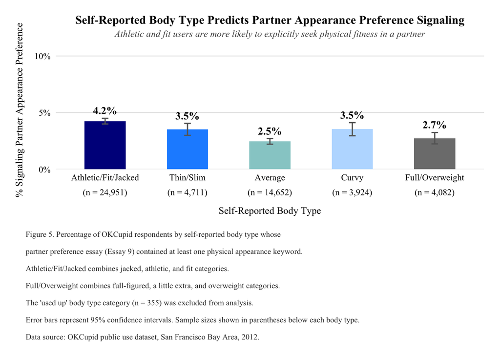

```r
# ── Step 0: Create partner_appearance_signal from Essay 9 ──

appearance_keywords <- c(
  "attractive", "good-looking", "good looking", "handsome",
  "beautiful", "fit body", "in shape", "toned", "physically fit",
  "fitness", "sexy", "appearance"
)

df <- df %>%
  mutate(
    essay9_clean = tolower(essay9),
    partner_appearance_signal = str_detect(
      essay9_clean,
      paste(appearance_keywords, collapse = "|")
    )
  )
# ─────────────────────────────────────────
# Body type vs partner appearance signaling
# in Essay 9
# ─────────────────────────────────────────

# ── Step 1: Simplify body type groups ──────

df <- df %>%
  mutate(
    body_type_simple = case_when(
      str_detect(body_type, "athletic|fit|jacked") ~ "Athletic/Fit/Jacked",
      str_detect(body_type, "thin|slim")           ~ "Thin/Slim",
      str_detect(body_type, "average")             ~ "Average",
      str_detect(body_type, "curvy")               ~ "Curvy",
      str_detect(body_type, "full|a little extra|overweight") ~ "Full/Overweight",
      str_detect(body_type, "used up")             ~ NA_character_,
      TRUE                                         ~ NA_character_
    ),
    body_type_simple = factor(body_type_simple, levels = c(
      "Athletic/Fit/Jacked", "Thin/Slim", "Average",
      "Curvy", "Full/Overweight"
    ))
  )

# ── Step 2: Prep plot data ──────────────────

plot_data_body <- df %>%
  filter(!is.na(body_type_simple),
         !is.na(partner_appearance_signal)) %>%
  group_by(body_type_simple) %>%
  summarise(
    n        = n(),
    mentions = sum(partner_appearance_signal, na.rm = TRUE),
    pct      = mentions / n * 100,
    se       = sqrt((pct/100 * (1 - pct/100)) / n) * 100,
    ci_lower = pct - 1.96 * se,
    ci_upper = pct + 1.96 * se,
    .groups  = "drop"
  )

# ── Step 3: Build x-axis labels ────────────

body_labels <- plot_data_body %>%
  mutate(label = paste0(body_type_simple, "\n(n = ",
                        scales::comma(n), ")")) %>%
  dplyr::select(body_type_simple, label) %>%
  deframe()

# ── Step 4: Compute y-axis limit dynamically ──

y_max <- ceiling(max(plot_data_body$ci_upper) * 1.15 / 5) * 5

# ── Step 5: Plot ────────────────────────────

plot_data_body %>%
  ggplot(aes(x = body_type_simple, y = pct,
             fill = body_type_simple)) +
  geom_col(width = 0.5) +
  geom_errorbar(aes(ymin = ci_lower, ymax = ci_upper),
                width = 0.08, color = "grey40",
                linewidth = 0.6) +
geom_text(aes(label = paste0(round(pct, 1), "%"),
              y = ci_upper),
          vjust = -0.6, size = 3.8,
          family = "Times New Roman",
          fontface = "bold") +
  scale_fill_manual(values = c(
    "Athletic/Fit/Jacked" = "#00008B",
    "Thin/Slim"           = "#1E90FF",
    "Average"             = "#96CDCD",
    "Curvy"               = "#BBDDFF",
    "Full/Overweight"     = "#7D7D7D"
  )) +
  scale_x_discrete(labels = body_labels) +
  scale_y_continuous(
    limits = c(0, y_max),
    breaks = seq(0, y_max, by = 5),
    labels = function(x) paste0(x, "%"),
    expand = expansion(mult = c(0, 0.05))
  ) +
  labs(
    title    = "Self-Reported Body Type Predicts Partner Appearance Preference Signaling",
    subtitle = "Athletic and fit users are more likely to explicitly seek physical fitness in a partner",
    x        = "Self-Reported Body Type",
    y        = "% Signaling Partner Appearance Preference",
    caption  = paste0(
      "Figure 5. Percentage of OKCupid respondents by self-reported body type whose\n",
      "partner preference essay (Essay 9) contained at least one physical appearance keyword.\n",
      "Athletic/Fit/Jacked combines jacked, athletic, and fit categories.\n",
      "Full/Overweight combines full-figured, a little extra, and overweight categories.\n",
      "The 'used up' body type category (n = ",
      scales::comma(sum(df$body_type == "used up", na.rm = TRUE)),
      ") was excluded from analysis.\n",
      "Error bars represent 95% confidence intervals. ",
      "Sample sizes shown in parentheses below each body type.\n",
      "Data source: OKCupid public use dataset, San Francisco Bay Area, 2012."
    )
  ) +
  theme_minimal(base_family = "Times New Roman") +
  theme(
    plot.title            = element_text(face = "bold", size = 12,
                                         hjust = 0.5,
                                         margin = margin(b = 4)),
    plot.subtitle         = element_text(size = 9.5, hjust = 0.5,
                                         color = "grey30",
                                         lineheight = 1.4,
                                         face = "italic",
                                         margin = margin(b = 12)),
    axis.title.x          = element_text(size = 10,
                                         margin = margin(t = 10)),
    axis.title.y          = element_text(size = 10,
                                         margin = margin(r = 10)),
    axis.text.x           = element_text(size = 9, color = "black",
                                         lineheight = 1.4),
    axis.text.y           = element_text(size = 9, color = "black"),
    panel.grid.major.x    = element_blank(),
    panel.grid.minor      = element_blank(),
    panel.grid.major.y    = element_line(color = "grey90",
                                         linewidth = 0.4),
    plot.caption          = element_text(size = 8, hjust = 0,
                                         color = "grey20",
                                         lineheight = 1.8,
                                         face = "plain",
                                         margin = margin(t = 16, l = 10)),
    plot.caption.position = "plot",
    plot.margin           = margin(t = 16, r = 16, b = 16, l = 16),
    legend.position       = "none"
  )
```

```r
ggsave(
  filename = "BodyTypeAppearanceSignaling.png",
  plot     = last_plot(),
  width    = 10,
  height   = 7,
  dpi      = 300,
  bg       = "white"
)
```